# Week_13_IP_part 2

Ayub Bett

1/28/2022

1. ##Defining the Question ##a) Specifying the Question Kira Plastinina (Links to an external site.) is a Russian brand that is sold through a defunct chain of retail stores in Russia, Ukraine, Kazakhstan, Belarus, China, Philippines, and Armenia. The brand’s Sales and Marketing team would like to understand their customer’s behavior from data that they have collected over the past year. More specifically, they would like to learn the characteristics of customer groups.

##c) Understanding the context This dataset consists of 18 columns, 10 numerical and 8 categorical with the column Revenue acting as the label column. Some of the attributes such as “Administrative”, “Administrative Duration”, “Informational”, “Informational Duration”, “Product Related” and “Product Related Duration” represents the number of different types of pages visited by the visitor in that session and total time spent in each of these page categories.

##d) experimental design taken 1) Load the dataset 2) Clean the dataset. 3) perform Exploratory data analysis 4) Implement the solution 5) Challenge the solution. 6) Follow up questions.

```r
#installing the datatable library
library(data.table)

#Loading the dataset
data2 <- read.csv("http://bit.ly/EcommerceCustomersDataset")

#View the top 6 entries
head(data2)
```

```
##   Administrative Administrative_Duration Informational Informational_Duration
## 1              0                       0             0                      0
## 2              0                       0             0                      0
## 3              0                      -1             0                     -1
## 4              0                       0             0                      0
## 5              0                       0             0                      0
## 6              0                       0             0                      0
##   ProductRelated ProductRelated_Duration BounceRates ExitRates PageValues
## 1              1                0.000000  0.20000000 0.2000000          0
## 2              2               64.000000  0.00000000 0.1000000          0
## 3              1               -1.000000  0.20000000 0.2000000          0
## 4              2                2.666667  0.05000000 0.1400000          0
## 5             10              627.500000  0.02000000 0.0500000          0
## 6             19              154.216667  0.01578947 0.0245614          0
##   SpecialDay Month OperatingSystems Browser Region TrafficType
## 1          0   Feb                1       1      1           1
## 2          0   Feb                2       2      1           2
## 3          0   Feb                4       1      9           3
## 4          0   Feb                3       2      2           4
## 5          0   Feb                3       3      1           4
## 6          0   Feb                2       2      1           3
##         VisitorType Weekend Revenue
## 1 Returning_Visitor   FALSE   FALSE
## 2 Returning_Visitor   FALSE   FALSE
## 3 Returning_Visitor   FALSE   FALSE
## 4 Returning_Visitor   FALSE   FALSE
## 5 Returning_Visitor    TRUE   FALSE
## 6 Returning_Visitor   FALSE   FALSE
```

```r
#Checking the shape of the dataframe
str(data2)
```

```
## 'data.frame':    12330 obs. of  18 variables:
##  $ Administrative         : int  0 0 0 0 0 0 0 1 0 0 ...
##  $ Administrative_Duration: num  0 0 -1 0 0 0 -1 -1 0 0 ...
##  $ Informational          : int  0 0 0 0 0 0 0 0 0 0 ...
##  $ Informational_Duration : num  0 0 -1 0 0 0 -1 -1 0 0 ...
##  $ ProductRelated         : int  1 2 1 2 10 19 1 1 2 3 ...
##  $ ProductRelated_Duration: num  0 64 -1 2.67 627.5 ...
##  $ BounceRates            : num  0.2 0 0.2 0.05 0.02 ...
##  $ ExitRates              : num  0.2 0.1 0.2 0.14 0.05 ...
##  $ PageValues             : num  0 0 0 0 0 0 0 0 0 0 ...
##  $ SpecialDay             : num  0 0 0 0 0 0 0.4 0 0.8 0.4 ...
##  $ Month                  : chr  "Feb" "Feb" "Feb" "Feb" ...
##  $ OperatingSystems       : int  1 2 4 3 3 2 2 1 2 2 ...
##  $ Browser                : int  1 2 1 2 3 2 4 2 2 4 ...
##  $ Region                 : int  1 1 9 2 1 1 3 1 2 1 ...
##  $ TrafficType            : int  1 2 3 4 4 3 3 5 3 2 ...
##  $ VisitorType            : chr  "Returning_Visitor" "Returning_Visitor" "Returning_Visitor" "Returning_Visitor" ...
##  $ Weekend                : logi  FALSE FALSE FALSE FALSE TRUE FALSE ...
##  $ Revenue                : logi  FALSE FALSE FALSE FALSE FALSE FALSE ...
```

We note that the dataset has 12330 rows and 18 columns

```r
#Checking for null values
colSums(is.na(data2))
```

```
##          Administrative Administrative_Duration           Informational
##                      14                      14                      14
##  Informational_Duration          ProductRelated ProductRelated_Duration
##                      14                      14                      14
##             BounceRates               ExitRates              PageValues
##                      14                      14                       0
##              SpecialDay                   Month        OperatingSystems
##                       0                       0                       0
##                 Browser                  Region             TrafficType
##                       0                       0                       0
##             VisitorType                 Weekend                 Revenue
##                       0                       0                       0
```

There are 14 missing values from the first 8 columns but since we have a pretty large dataframe we drop them.

```r
#Dropping the missing values
data <- na.omit(data2)

#Checking for changes
colSums(is.na(data))
```

```
##          Administrative Administrative_Duration           Informational
##                       0                       0                       0
##  Informational_Duration          ProductRelated ProductRelated_Duration
##                       0                       0                       0
##             BounceRates               ExitRates              PageValues
##                       0                       0                       0
##              SpecialDay                   Month        OperatingSystems
##                       0                       0                       0
##                 Browser                  Region             TrafficType
##                       0                       0                       0
##             VisitorType                 Weekend                 Revenue
##                       0                       0                       0
```

```r
#Checking if there are duplicated entries
dupli <- data[duplicated(data),]
dupli
```

```
##       Administrative Administrative_Duration Informational
## 159                0                       0             0
## 179                0                       0             0
## 419                0                       0             0
## 457                0                       0             0
## 484                0                       0             0
## 513                0                       0             0
## 555                0                       0             0
## 590                0                       0             0
## 660                0                       0             0
## 775                0                       0             0
## 873                0                       0             0
## 890                0                       0             0
## 923                0                       0             0
## 948                0                       0             0
```

[output cut: 457 more lines]

```r
#Checking unique values in the various columns
unique(data$Weekend)
```

```
## [1] FALSE  TRUE
```

###EXPLORATORY DATA ANALYSIS ###UNIVARIATE ANALYSIS

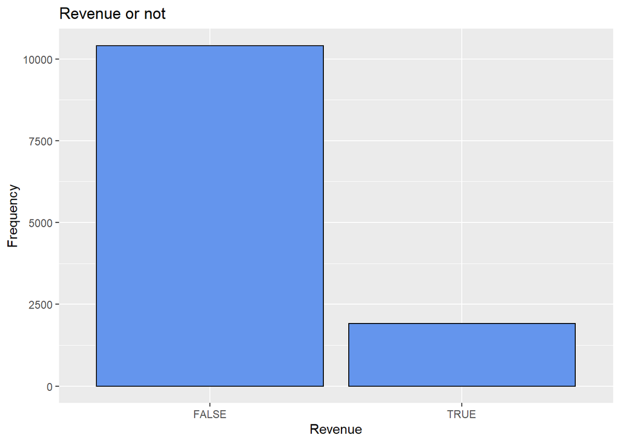

```r
library(ggplot2)
ggplot(data, aes(x = Revenue)) +
  geom_bar(fill = "cornflowerblue",
           color="black") +
  labs(x = "Revenue",
       y = "Frequency",
       title = "Revenue or not")
```

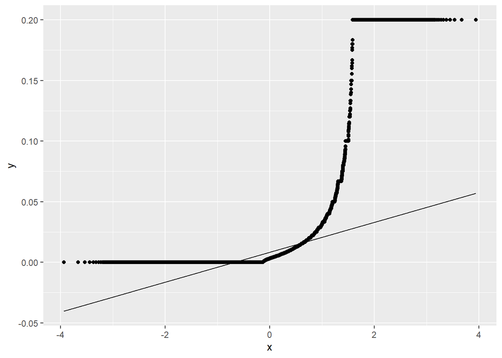

```r
# QQ Plot for bounce rates
ggplot(data, aes(sample = BounceRates)) +
  geom_qq() +
  geom_qq_line()
```

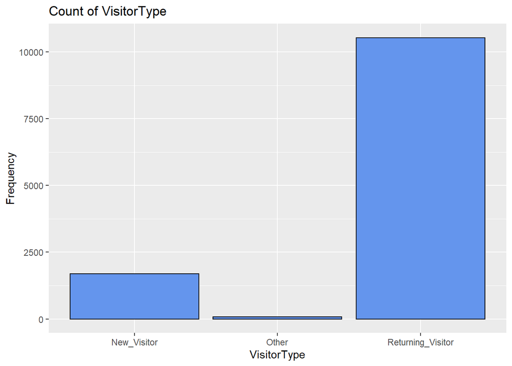

```r
library(ggplot2)
ggplot(data, aes(x = VisitorType)) +
  geom_bar(fill = "cornflowerblue",
           color="black") +
  labs(x = "VisitorType",
       y = "Frequency",
       title = "Count of VisitorType")
```

From the above barplot we find that majority of them visitors are the returning ones.

###BIVARIATE ANALYSIS

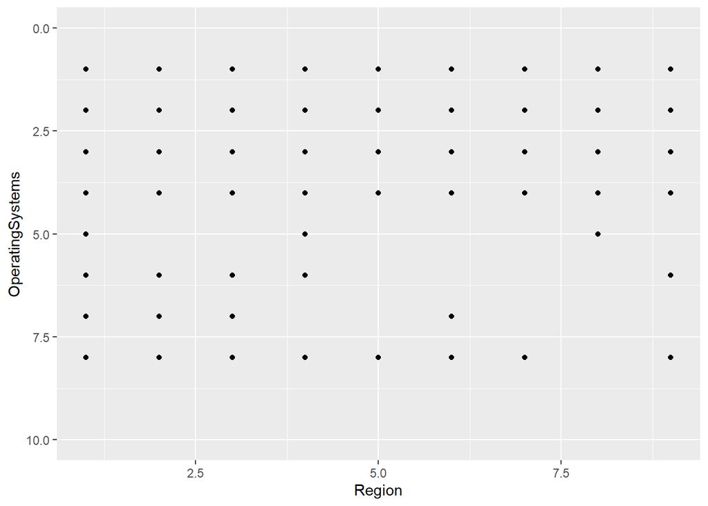

```r
# scatter plot
ggplot(data, aes(x = Region, y = OperatingSystems)) +
  geom_point() +
  ylim(10, 0)
```

From the scatter plot we note that The operating systems in theregions range 0 and 8

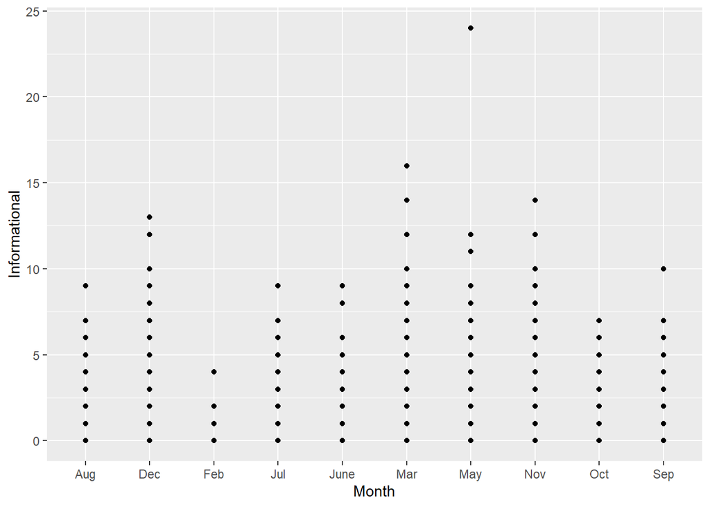

```r
#Scatter plot of months vs bounce rate
ggplot(data,
       aes(x = Month,
           y = Informational)) +
  geom_point()
```

###FEATURE ENGINERING ###One-Hot Encoding

```r
library(caret)
library(dplyr)
dmy <- dummyVars(" ~ .", data = data, fullRank = T)
data_transformed <- data.frame(predict(dmy, newdata = data))

head(data_transformed)
```

```
##   Administrative Administrative_Duration Informational Informational_Duration
## 1              0                       0             0                      0
## 2              0                       0             0                      0
## 3              0                      -1             0                     -1
## 4              0                       0             0                      0
## 5              0                       0             0                      0
## 6              0                       0             0                      0
##   ProductRelated ProductRelated_Duration BounceRates ExitRates PageValues
## 1              1                0.000000  0.20000000 0.2000000          0
## 2              2               64.000000  0.00000000 0.1000000          0
## 3              1               -1.000000  0.20000000 0.2000000          0
## 4              2                2.666667  0.05000000 0.1400000          0
## 5             10              627.500000  0.02000000 0.0500000          0
## 6             19              154.216667  0.01578947 0.0245614          0
##   SpecialDay MonthDec MonthFeb MonthJul MonthJune MonthMar MonthMay MonthNov
```

[output cut: 20 more lines]

```r
head(data_transformed)
```

```
##   Administrative Administrative_Duration Informational Informational_Duration
## 1              0                       0             0                      0
## 2              0                       0             0                      0
## 3              0                      -1             0                     -1
## 4              0                       0             0                      0
## 5              0                       0             0                      0
## 6              0                       0             0                      0
##   ProductRelated ProductRelated_Duration BounceRates ExitRates PageValues
## 1              1                0.000000  0.20000000 0.2000000          0
## 2              2               64.000000  0.00000000 0.1000000          0
## 3              1               -1.000000  0.20000000 0.2000000          0
## 4              2                2.666667  0.05000000 0.1400000          0
## 5             10              627.500000  0.02000000 0.0500000          0
## 6             19              154.216667  0.01578947 0.0245614          0
##   SpecialDay MonthDec MonthFeb MonthJul MonthJune MonthMar MonthMay MonthNov
```

[output cut: 20 more lines]

```r
#Now that we have encoded our categorical columns lets drop the target column Revenue
df5<-data_transformed[,c(-27)]
head(df5)
```

```
##   Administrative Administrative_Duration Informational Informational_Duration
## 1              0                       0             0                      0
## 2              0                       0             0                      0
## 3              0                      -1             0                     -1
## 4              0                       0             0                      0
## 5              0                       0             0                      0
## 6              0                       0             0                      0
##   ProductRelated ProductRelated_Duration BounceRates ExitRates PageValues
## 1              1                0.000000  0.20000000 0.2000000          0
## 2              2               64.000000  0.00000000 0.1000000          0
## 3              1               -1.000000  0.20000000 0.2000000          0
## 4              2                2.666667  0.05000000 0.1400000          0
## 5             10              627.500000  0.02000000 0.0500000          0
## 6             19              154.216667  0.01578947 0.0245614          0
##   SpecialDay MonthDec MonthFeb MonthJul MonthJune MonthMar MonthMay MonthNov
```

[output cut: 20 more lines]

```r
#Finding the optimal number of K
#Loading the necessary libraries

library(factoextra)
```

```r
library(cluster)
#Elbow Method for finding the optimal number of clusters
set.seed(123)
# Compute and plot wss for k = 2 to k = 15.
k.max <- 15
data <- df5
wss <- sapply(1:k.max,
              function(k){kmeans(df5, k, nstart=50,iter.max = 15 )$tot.withinss})
wss
```

```
##  [1] 45790835063 21541586825 13211055526  9266726420  6026429062  4761144556
##  [7]  3975139851  2603589283  2135705142  1823195225  1641662089  1500846496
## [13]  1424826261  1328249095  1250098454
```

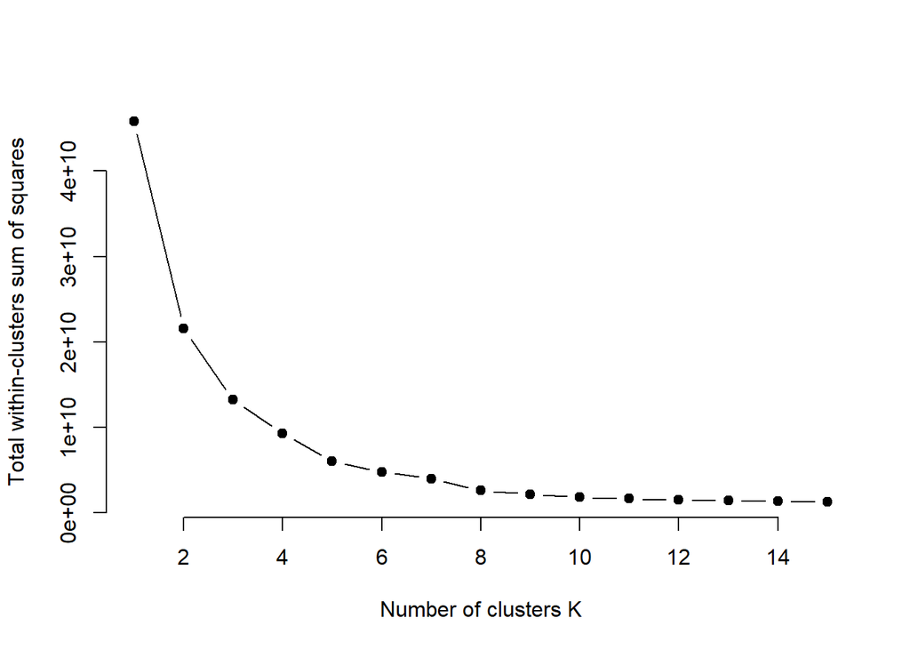

```r
plot(1:k.max, wss,
     type="b", pch = 19, frame = FALSE,
     xlab="Number of clusters K",
     ylab="Total within-clusters sum of squares")
```

Our curve has an elbow at K=6 so we use 6 as our optimal K

```r
#Setting the seed
set.seed(1)

#perform k-means clustering with k = 4 clusters
km <- kmeans(df5, centers = 6, nstart = 25)

#view results
km
```

```
## K-means clustering with 6 clusters of sizes 3084, 10, 1187, 7496, 413, 126
##
## Cluster means:
##   Administrative Administrative_Duration Informational Informational_Duration
## 1       3.044099               113.58532     0.6686122               44.42739
## 2      14.700000              1558.19631     7.4000000             1034.03250
## 3       4.267902               152.44994     1.1288964               77.46693
## 4       1.425160                44.65623     0.2214514               12.42605
## 5       5.716707               201.47127     1.7917676              150.75410
## 6       7.150794               251.21087     2.6269841              240.20573
##   ProductRelated ProductRelated_Duration BounceRates  ExitRates PageValues
## 1       38.28405                1448.937 0.008952555 0.02477484   9.449354
## 2      512.40000               30277.952 0.004504685 0.01839164   3.543312
## 3       75.50969                3171.195 0.007132260 0.02156909   8.222298
## 4       12.39661                 310.733 0.031118652 0.05555006   4.067663
```

[output cut: 1930 more lines]

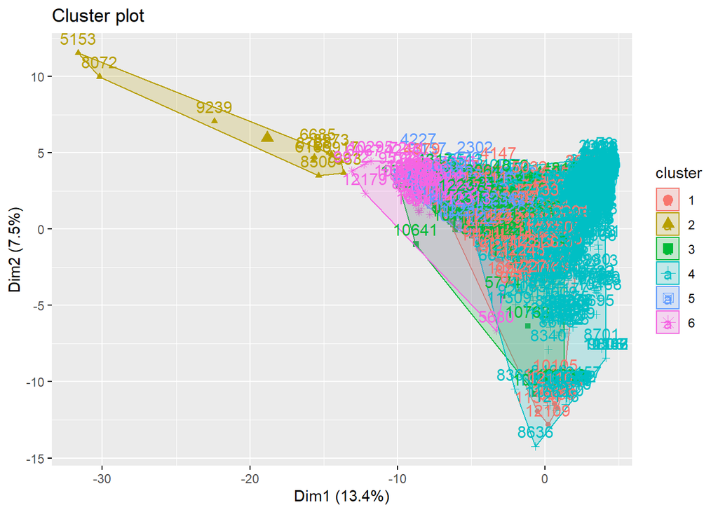

```r
library(factoextra)
library(cluster)
#plot results of final k-means model
fviz_cluster(km, data = df5)
```

```r
#find means of each cluster
#aggregate(df5, by=list(cluster=km$cluster), mean)
```

```r
#library(cluster)

#Finding the best linkage method to use
#define linkage methods
#m <- c( "average", "single", "complete", "ward")
#names(m) <- c( "average", "single", "complete", "ward")

#function to compute agglomerative coefficient
#ac <- function(x) {
 # agnes(df5, method = m)$ac
#}

#calculate agglomerative coefficient for each clustering linkage method
#sapply(m, ac)
```

```r
#library(cluster)
#perform hierarchical clustering using Ward's minimum variance
#clust <- agnes(df5, method = "ward")

#produce dendrogram
#pltree(clust, cex = 0.6, hang = -1, main = "Dendrogram")
```

```r
#str(df5)
```